# Дисперсионный анализ (ANOVA)

Литвинцев И.С

## Одномерный двухфакторный дисперсионный анализ с фиксированными эффектами

### 1. Подготовка данных

Исследуются данные о недоношенных младенцах, у которых вовремя не закрылся артериальный проток. Выполним проверку значимости факторов пола (Sex) и типа терапии (therapy) на зависимую переменную “масса при рождении” (Weight1).

Факторы:

1. Sex - Пол (1-м, 2-д)
2. therapy - Вид терапии (1 - только операция; 2 - мед.лечение + операция; 3 - только медикаментозное лечение (Педеа))

Зависимая переменная:

1. Weight1 - Масса при рождении

```r
data <- read.csv("C:/Users/806263/Desktop/SPbU/Магистратура Матмех (2017-2019)/Применение статистических методов к реальным данным/Данные/baseMA.csv", sep = ";", dec = ".")

data <- data[, c("Sex", "therapy", "Weight1")]
data <- na.omit(data)
head(data)
```

```
##   Sex therapy Weight1
## 1   1       3     980
## 2   1       3    1930
## 3   2       3    1090
## 4   1       2    1220
## 5   2       3     914
## 6   2       3    1180
```

Посчитаем количество элементов в каждой группе.

```r
num_elements <- tapply(X = data$Weight1, INDEX = list(data$Sex, data$therapy), FUN = length); num_elements
```

```
##    1  2  3
## 1 42 32 31
## 2 27 10 13
```

Видим, что число элементов в группах разное. Для дальнейшего анализа нам потребуется одинаковое количество наблюдений в каждой группе. Добьемся этого. А также разобьем данные по группам основываясь на значениях двух факторов - Sex и therapy.

```r
K <- min(num_elements)
split_data <- split(data, list(data$Sex, data$therapy))

# Вспомогательная функция. Возвращает случайное подмножество df, состоящее из K элементов
get_group <- function(df){
  #ind <- sample(seq(1, nrow(df)), K)
  ind <- seq(1,K)
  return(df[ind,])
}

groups <- lapply(split_data, get_group); groups
```

```
## $`1.1`
##    Sex therapy Weight1
## 22   1       1     850
## 23   1       1    1135
## 26   1       1     996
## 27   1       1     990
## 28   1       1     760
## 30   1       1     830
## 32   1       1     750
## 34   1       1     970
## 38   1       1     880
## 39   1       1     870
##
## $`2.1`
##    Sex therapy Weight1
```

[output cut: 62 more lines]

Полученные группы сведем в один data frame для того, чтобы в дальнейшем подать его на вход функции aov() для сверки результатов.

```r
data <- rbind(groups$`1.1`, groups$`2.1`, groups$`1.2`, groups$`2.2`, groups$`1.3`, groups$`2.3`)
```

### 2. Модель одномерного двухфакторного дисперсионного анализа с фиксированными эффектами

Данный вариант дисперсионного анализа применяется тогда, когда изучается влияние двух факторов на исследуемый признак. При этом можно выявить влияние отдельных факторов, а также влияние взаимодействия этих факторов. В результате вычисления данного варианта критерия получаются три эмпирических значения и, следовательно, три вывода.

Модель имеет вид:

$$x_{ijk} = \mu + \alpha_i + \beta_j + (\alpha \beta)_{ij} + \varepsilon_{ijk}, \quad i \in 1:I, \: j \in 1:J, \: k=1:K$$

где ошибки $\varepsilon_{ij} \sim N(0,\sigma^2)$ и независимы, $\alpha_i$ – дифференциальный (главный, фиксированный) эффект фактора Sex, $\beta_j$ – дифференциальный эффект фактора therapy, величина $(\alpha \beta)_{ij}$ – эффект взаимодействия двух факторов; $\mu$ – генеральное среднее.

Найдем оценки параметров по формулам:
$$\hat{\mu} = \bar{x}_{***} = \frac{1}{IJK}\sum_{i=1}^{I}\sum_{k=1}^{K} \sum_{j=1}^{J} x_{ijk}$$
$$\hat{\alpha_i} = \bar{x}_{i**} -\bar{x}_{***} = \frac{1}{JK}\sum_{j=1}^{J}\sum_{k=1}^{K} x_{ijk} - \bar{x}_{***}$$
$$\hat{\beta_j} = \bar{x}_{*j*} -\bar{x}_{***} = \frac{1}{IK}\sum_{i=1}^{I}\sum_{k=1}^{K} x_{ijk} - \bar{x}_{***}$$
$$\widehat{(\alpha\beta)}_{ij} = \bar{x}_{ij*} -\bar{x}_{i**}-\bar{x}_{*j*}+\bar{x}_{***} = \frac{1}{K}\sum_{k=1}^{K} x_{ijk} - \bar{x}_{i**}- \bar{x}_{*j*} +\bar{x}_{***}$$
Рассчитаем $\bar{x}_{***}, \bar{x}_{i**}, \bar{x}_{*j*}, \bar{x}_{ij*}$:

```r
x_mean <- mean(data$Weight1); x_mean
```

```
## [1] 1118.483
```

```r
x_mean_i <- tapply(X = data$Weight1, INDEX = data$Sex, FUN = mean); x_mean_i
```

```
##        1        2
## 1091.700 1145.267
```

```r
x_mean_j <- tapply(X = data$Weight1, INDEX = data$therapy, FUN = mean); x_mean_j
```

```
##       1       2       3
## 1010.05  997.70 1347.70
```

```r
x_mean_ij <- tapply(X = data$Weight1, INDEX = list(data$Sex, data$therapy), FUN = mean); x_mean_ij
```

```
##        1      2      3
## 1  903.1  969.0 1403.0
## 2 1117.0 1026.4 1292.4
```

Теперь можно легко найти оценки:

```r
alpha <- x_mean_i - x_mean; alpha
```

```
##         1         2
## -26.78333  26.78333
```

```r
beta <- x_mean_j - x_mean; beta
```

```
##         1         2         3
## -108.4333 -120.7833  229.2167
```

```r
alpha_beta <- x_mean_ij - matrix(x_mean_i, 2, 3) - t(matrix(x_mean_j, 3, 2)) + x_mean; alpha_beta
```

```
##           1         2         3
## 1 -80.16667 -1.916667  82.08333
## 2  80.16667  1.916667 -82.08333
```

### 3. Проверка гипотез

#### 3.1. Гипотеза об отсутствии эффекта фактора пола (Sex)

$$H_0: \alpha_1 = ... = \alpha_I = 0$$
$$H_1: \alpha_1 \neq ... \neq \alpha_I \neq 0$$
Для проверки этой гипотезы используется статистика
$$F = \frac{MQ_{A}}{MQ_{R}} \sim F(df_{A}, df_R),$$

где $Q_R$ – остаточная сумма квадратов основной модели:
$$Q_R = \sum_{i,j,k} ( x_{ijk} - \hat{\mu} - \hat{\alpha_i} - \hat{\beta_j} + \widehat{(\alpha \beta)}_{ij})^2 = \sum_{i,j,k} (x_{ijk} - \bar{x}_{ij*})^2, \quad MQ_R = \frac{Q_R}{df_R}, \quad df_R = IJ(K-1)$$
Найдем чему равно $Q_R$.

```r
I <- length(unique(data$Sex)); J <- length(unique(data$therapy))

# names(groups) = {"1.1" "2.1" "1.2" "2.2" "1.3" "2.3"}
Q_R <- 0
for (name in names(groups)){
  str_ij <- strsplit(name, "[.]")
  ij <- as.vector(sapply(str_ij, as.numeric))
  tmp_vec <- groups[[name]]$Weight1 - x_mean_ij[ij[1], ij[2]]
  Q_R <- Q_R + tmp_vec%*%tmp_vec
}
Q_R
```

```
##         [,1]
## [1,] 5119140
```

Найдем $Q_A$ – остаточную сумму квадратов усеченной по фактору пола модели:
$$MQ_A = \frac{Q_A}{df_A}, \quad Q_A = \sum_{i,j,k}(\hat{\alpha}_i)^2 = JK \sum_i^I (\alpha_i)^2, \quad df_A = I-1,$$

```r
Q_A <- alpha%*%alpha*J*K; Q_A
```

```
##          [,1]
## [1,] 43040.82
```

В рамках истинности нулевой гипотезы $H_0: \alpha_1 = ... = \alpha_I = 0$ необходимо проверить, что данные в группах подчиняются нормальному закону распределения. Для этого построим гистограмму ошибок усеченной по полу модели и проведем тест Шапиро-Уилка. Ошибки найдем по формуле:
$$\varepsilon_{ijk} = x_{ijk} - \hat{\mu} - \hat{\beta_j} - \widehat{(\alpha \beta)}_{ij} = x_{ijk} - \bar{x}_{ij*} + \bar{x}_{i**} - \bar{x}_{***}$$

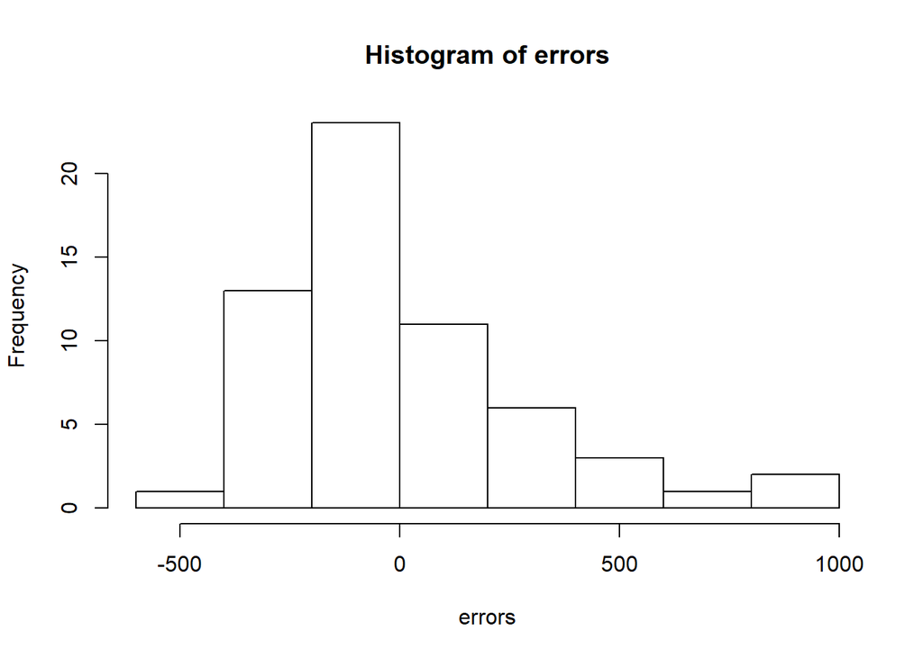

```r
errors <- c()
for (name in names(groups)){
  str_ij <- strsplit(name, "[.]")
  ij <- as.vector(sapply(str_ij, as.numeric))
  tmp_vec <- groups[[name]]$Weight1 - x_mean_ij[ij[1], ij[2]] + x_mean_i[ij[1]]-x_mean
  errors <- append(errors, tmp_vec)
}
hist(errors)
```

```r
shapiro.test(errors)
```

```
##
##  Shapiro-Wilk normality test
##
## data:  errors
## W = 0.90991, p-value = 0.0003083
```

P-значение теста Шапиро-Уилка достаточно мало. Следовательно, можно сказать, что данные в группах не имеют нормального распределения и лучше воспользоваться непараметрическим аналогом критерия.

Несмотря на это, продолжим анализ. Посчитаем чему равна статистика $F = \frac{MQ_{A}}{MQ_{R}} \sim F(df_{A}, df_R)$ и p-значение распределения Фишера.

```r
df_R <- I*J*K-I*J
df_A <- I-1
f_A <- (Q_A/Q_R)*df_R/df_A; f_A
```

```
##           [,1]
## [1,] 0.4540224
```

```r
p_A <- 1-pf(f_A, df_A, df_R); p_A
```

```
##           [,1]
## [1,] 0.5033051
```

При уровне значимости $\alpha = 0.05$ нет оснований отклонить гипотезу. Следовательно, нет значимого влияния фактора пола на исследуемую переменную веса.

#### 3.2. Гипотеза об отсутствии эффекта фактора вид терапии (therapy)

$$H_0: \beta_1 = ... = \beta_J = 0$$
$$H_1: \beta_1 \neq ... \neq \beta_J \neq 0$$
Для проверки этой гипотезы используется статистика
$$F = \frac{MQ_{B}}{MQ_{R}} \sim F(df_{B}, df_R),$$
где $Q_B$ – остаточная сумма квадратов усеченной по фактору терапии модели:
$$MQ_B = \frac{Q_B}{df_B}, \quad Q_B = \sum_{i,j,k}(\hat{\beta}_j)^2 = IK \sum_j^J (\hat{\beta}_j)^2, \quad df_B = J-1,$$
Проверим, что данные в группах подчиняются нормальному закону распределения. Для этого построим гистограмму ошибок усеченной модели и проведем тест Шапиро-Уилка.

$$\varepsilon_{ijk} = x_{ijk} - \hat{\mu} - \hat{\alpha}_i - \widehat{(\alpha \beta)}_{ij} = x_{ijk} - \bar{x}_{ij*} + \bar{x}_{*j*} - \bar{x}_{***}$$

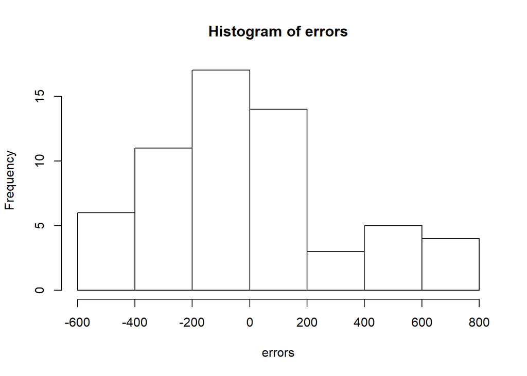

```r
errors <- c()
for (name in names(groups)){
  str_ij <- strsplit(name, "[.]")
  ij <- as.vector(sapply(str_ij, as.numeric))
  tmp_vec <- groups[[name]]$Weight1 - x_mean_ij[ij[1], ij[2]] + x_mean_j[ij[2]]-x_mean
  errors <- append(errors, tmp_vec)
}
hist(errors)
```

```r
shapiro.test(errors)
```

```
##
##  Shapiro-Wilk normality test
##
## data:  errors
## W = 0.94046, p-value = 0.005678
```

Опять получили не нормальное распределение ошибок, но продолжим.

Посчитаем чему равна статистика $F = \frac{MQ_{B}}{MQ_{R}} \sim F(df_{B}, df_R)$ и p-значение распределения Фишера.

```r
Q_B <- I*K*beta%*%beta; Q_B
```

```
##         [,1]
## [1,] 1577734
```

```r
df_B <- J-1
f_B <- (Q_B/Q_R)*df_R/df_B; f_B
```

```
##          [,1]
## [1,] 8.321478
```

```r
p_B <- 1-pf(f_B, df_B, df_R); p_B
```

```
##              [,1]
## [1,] 0.0007075746
```

При уровне значимости $\alpha = 0.05$ отклоняем гипотезу. Т.е. влияние фактора вид терапии значимо для веса.

#### 3.3. Гипотеза об отсутствии эффекта взаимодействия двух факторов (Sex*therapy)

$$H_0: (\alpha\beta)_{11} = ... = (\alpha\beta)_{IJ} = 0$$
$$H_1: (\alpha\beta)_{11} \neq ... \neq (\alpha\beta)_{IJ} \neq 0$$
Для проверки этой гипотезы используется статистика
$$F = \frac{MQ_{AB}}{MQ_{R}} \sim F(df_{AB}, df_R),$$
где $Q_{AB}$ – остаточная сумма квадратов модели, усеченной по взаимодействующим факторам:
$$MQ_{AB} = \frac{Q_{AB}}{df_{AB}}, \quad Q_{AB} = \sum_{i,j,k}(\widehat{\alpha\beta)}_{ij})^2 = K \sum_j^J\sum_i^I (\widehat{\alpha\beta)}_{ij})^2, \quad df_{AB} = (I-1)(J-1),$$
Проверим, что данные в группах подчиняются нормальному закону распределения. Для этого построим гистограмму ошибок усеченной модели и проведем тест Шапиро-Уилка.

$$\varepsilon_{ijk} = x_{ijk} - \hat{\mu} - \hat{\alpha}_i - \hat{\beta}_j = x_{ijk} - \bar{x}_{i**} - \bar{x}_{*j*} + \bar{x}_{***}$$

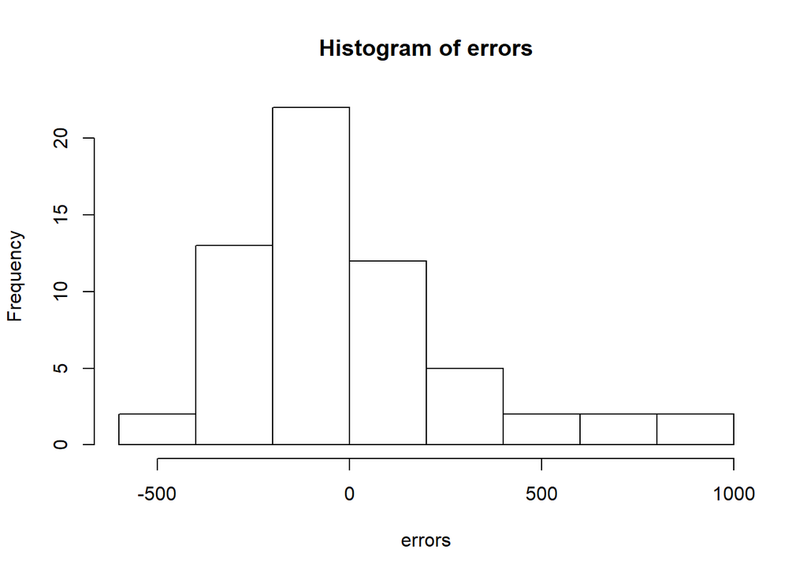

```r
errors <- c()
for (name in names(groups)){
  str_ij <- strsplit(name, "[.]")
  ij <- as.vector(sapply(str_ij, as.numeric))
  tmp_vec <- groups[[name]]$Weight1 - x_mean_i[ij[1]] - x_mean_j[ij[2]]  + x_mean
  errors <- append(errors, tmp_vec)
}
hist(errors)
```

```r
shapiro.test(errors)
```

```
##
##  Shapiro-Wilk normality test
##
## data:  errors
## W = 0.89481, p-value = 8.553e-05
```

Такая же не нормальная ситуация. Продолжаем.

Посчитаем чему равна статистика $F = \frac{MQ_{AB}}{MQ_{R}} \sim F(df_{AB}, df_R)$ и p-значение распределения Фишера.

```r
df_AB <- (I-1)*(J-1)
Q_AB <- K*(alpha_beta[1,]%*%alpha_beta[1,] + alpha_beta[2,]%*%alpha_beta[2,]); Q_AB
```

```
##          [,1]
## [1,] 263360.8
```

```r
f_AB <- (Q_AB/Q_R)*df_R/df_AB; f_AB
```

```
##         [,1]
## [1,] 1.38905
```

```r
p_AB <- 1 - pf(f_AB, df_AB, df_R); p_AB
```

```
##           [,1]
## [1,] 0.2580764
```

p-значение больше уровня значимости $\alpha = 0.05$, следовательно влияние фактора взаимодействия незначимо.

### 4. Проверка результатов

Воспользовавшись встроенной функцией aov(), убедимся, что рассчеты верны. Но не забудем преобразовать тип переменных Sex и therapy в факторы, иначе результат будет не корректным.

```r
data$Sex <- factor(data$Sex); data$therapy <- factor(data$therapy)
aov <- aov(Weight1~Sex + therapy + Sex*therapy, data)
summary(aov)
```

```
##             Df  Sum Sq Mean Sq F value   Pr(>F)
## Sex          1   43041   43041   0.454 0.503305
## therapy      2 1577734  788867   8.321 0.000708 ***
## Sex:therapy  2  263361  131680   1.389 0.258076
## Residuals   54 5119140   94799
## ---
## Signif. codes:  0 '***' 0.001 '**' 0.01 '*' 0.05 '.' 0.1 ' ' 1
```

Для удобства проверки ниже приведены получившиеся p-значения

```r
p <- c(p_A,p_B,p_AB); names(p) <- c("Sex", "therapy", "Sex:therapy" ); p
```

```
##          Sex      therapy  Sex:therapy
## 0.5033050724 0.0007075746 0.2580764043
```

Подытоживая, можно еще раз сказать, что на исследуемый признак веса значимое влияние оказал только вид терапии. Пол и эффект взаимодействия пола и терапии значимого влияния не оказывают.